# Lab 1: Building your Agent

The agent is comprised of a router using OpenAI function calling, and a set of three tools: a database lookup tool, a data analysis tool, and a code generator to create graphs.

[figure not shown]

The agent can lookup information from a local file, perform analysis on that information, and graph results. The example local file is a log of transactions at a local store. The agent can help the store owners understand trends and anomalies in their sales data.

## Importing necessary libraries

```python
from openai import OpenAI
import pandas as pd
import json
import duckdb
from pydantic import BaseModel, Field
from IPython.display import Markdown

from helper import get_openai_api_key
```

💻 **Access `requirements.txt` and `helper.py` files:** 1) click on the *"File"* option on the top menu of the notebook and then 2) click on *"Open"*. For more help, please see the *"Appendix – Tips, Help, and Download"* Lesson.

🚨 **Different Run Results:** The output generated by AI chat models can vary with each execution due to their dynamic, probabilistic nature. Your results might differ from those shown in the video.

## Initializing the OpenAI client

```python
# initialize the OpenAI client
openai_api_key = get_openai_api_key()
client = OpenAI(api_key=openai_api_key)

MODEL = "gpt-4o-mini"
```

## Defining the tools

Let's start by creating the three tools the agent will be able to use.

### Tool 1: Database Lookup

This first tool reads from a local parquet file that contains the transaction data.

```python
# define the path to the transactional data
TRANSACTION_DATA_FILE_PATH = 'data/Store_Sales_Price_Elasticity_Promotions_Data.parquet'
```

This database lookup tool works using three steps.

[figure not shown]

1. First, it creates the SQL table from a local file, if not already done.
2. Second, it translates the original prompt into an sql query (using an LLM call).
3. Finally, it runs that query against the database.

```python
# prompt template for step 2 of tool 1
SQL_GENERATION_PROMPT = """
Generate an SQL query based on a prompt. Do not reply with anything besides the SQL query.
The prompt is: {prompt}

The available columns are: {columns}
The table name is: {table_name}
"""
```

```python
# code for step 2 of tool 1
def generate_sql_query(prompt: str, columns: list, table_name: str) -> str:
    """Generate an SQL query based on a prompt"""
    formatted_prompt = SQL_GENERATION_PROMPT.format(prompt=prompt,
                                                    columns=columns,
                                                    table_name=table_name)

    response = client.chat.completions.create(
        model=MODEL,
        messages=[{"role": "user", "content": formatted_prompt}],
    )

    return response.choices[0].message.content
```

````python
# code for tool 1
def lookup_sales_data(prompt: str) -> str:
    """Implementation of sales data lookup from parquet file using SQL"""
    try:

        # define the table name
        table_name = "sales"

        # step 1: read the parquet file into a DuckDB table
        df = pd.read_parquet(TRANSACTION_DATA_FILE_PATH)
        duckdb.sql(f"CREATE TABLE IF NOT EXISTS {table_name} AS SELECT * FROM df")

        # step 2: generate the SQL code
        sql_query = generate_sql_query(prompt, df.columns, table_name)
        # clean the response to make sure it only includes the SQL code
        sql_query = sql_query.strip()
        sql_query = sql_query.replace("```sql", "").replace("```", "")

        # step 3: execute the SQL query
        result = duckdb.sql(sql_query).df()

        return result.to_string()
    except Exception as e:
        return f"Error accessing data: {str(e)}"
````

Great! Now let's test the first tool and make sure it worked correctly.

```python
example_data = lookup_sales_data("Show me all the sales for store 1320 on November 1st, 2021")
print(example_data)
```

```
    Store_Number  SKU_Coded  Product_Class_Code  Sold_Date  Qty_Sold  Total_Sale_Value  On_Promo
0           1320    6173050               22875 2021-11-01         1          4.990000         0
1           1320    6174250               22875 2021-11-01         1          0.890000         0
2           1320    6176200               22975 2021-11-01         2         99.980003         0
3           1320    6176800               22800 2021-11-01         1         14.970000         0
4           1320    6177250               22975 2021-11-01         1          6.890000         0
5           1320    6177300               22800 2021-11-01         1          9.990000         0
6           1320    6177350               22800 2021-11-01         2         16.980000         0
7           1320    6177700               22875 2021-11-01         1          3.190000         0
8           1320    6178000               22875 2021-11-01         2          6.380000         0
9           1320    6178250               22800 2021-11-01         1         16.590000         0
10          1320    6179250               24400 2021-11-01         1         14.990000         0
11          1320    6179300               22800 2021-11-01         2          9.980000         0
12          1320    6179400               24400 2021-11-01         2         29.980000         0
13          1320    6179450               24400 2021-11-01         1         14.990000         0
```

[output cut: 16 more lines]

### Tool 2: Data Analysis

The second tool can analyze the returned data and display conclusions to users.

[figure not shown]

```python
# Construct prompt based on analysis type and data subset
DATA_ANALYSIS_PROMPT = """
Analyze the following data: {data}
Your job is to answer the following question: {prompt}
"""
```

```python
# code for tool 2
def analyze_sales_data(prompt: str, data: str) -> str:
    """Implementation of AI-powered sales data analysis"""
    formatted_prompt = DATA_ANALYSIS_PROMPT.format(data=data, prompt=prompt)

    response = client.chat.completions.create(
        model=MODEL,
        messages=[{"role": "user", "content": formatted_prompt}],
    )

    analysis = response.choices[0].message.content
    return analysis if analysis else "No analysis could be generated"
```

This tool is relatively simple, but let's still test it out to be sure things are working correctly.

```python
print(analyze_sales_data(prompt="what trends do you see in this data",
                         data=example_data))
```

```
Based on the provided sales data from store number 1320, here are several trends and observations that can be identified:

1. **Promotional Activity**:
   - There is only one instance of a product being sold on promotion (SKU 6195800), which indicates that the majority of sales did not occur during promotional events (On_Promo = 0 for most transactions). This may suggest a potential opportunity to leverage promotions more frequently to boost sales.

2. **Product Class Distribution**:
   - The sold products span various product class codes (22800, 22975, 24400, etc.), with varying quantities and total sale values. This indicates a diverse product mix but does not necessarily show which class is performing the best purely based on this single day's data.

3. **Quantity Sold vs Total Sale Value**:
   - There is a mix of low and high priced products. For example, SKU 6176200 (Product Class Code 22975) is sold for $99.98, while several other SKUs are sold for below $10. The quantity sold also varies; some high-value items are sold in small quantities (like SKU 6176200) and some low-value items …
   - Analyzing the sales data further could lead to insights on whether selling higher quantity lower-cost items could drive overall sales revenue while also maintaining a variety of higher-cost items for revenue balance.

4. **Top-Selling SKUs**:
   - SKU 6190050 (Product Class Code 24425) is noteworthy, with 5 units sold. This could be a top-selling product that merits further examination to see if it has consistent demand or particular attributes that make it appealing to customers.

5. **Revenue Generation**:
   - The total sale value for each SKU indicates which items contribute most significantly to overall sales revenue. For instance, SKU 6176200 has a high total sale value indicating it could be a key product for the store (despite low quantities sold).

6. **Sales Patterns**:
   - The sales on the specific date (November 1, 2021) showcase potential customer purchasing patterns. While it’s a snapshot of just one day, further analysis over multiple days could reveal trends related to high sales days, potential seasonal effects, or customer preferences.

7. **Product Variability**:
   - The variety in SKU codes suggests that the store carries a wide range of products. Determining which items have repeat purchases or that become staples could help in inventory management.

8. **Opportunity for Bundling**:
   - Given the diversity of products sold, there could be potential for product bundling or cross-selling strategies where related items (especially those with lower sale values) are promoted together.

To draw definitive conclusions about trends, it would be beneficial to analyze this dataset over a longer period and in comparison with additional data, such as customer demographics, competitor pricing, and external factors (like holidays or events) which could impact sales.
```

### Tool 3: Data Visualization

The third tool generates python code to create the requested graphs from the returned data of the first tool. It consists of two steps:

[figure not shown]

1. First, it creates the chart configuration: chart type, title, data, lables for x-axis and y-axis (using an LLM call).
2. Second, it generates the python code based on the chart configuration of the first step (using an LLM call).

```python
# prompt template for step 1 of tool 3
CHART_CONFIGURATION_PROMPT = """
Generate a chart configuration based on this data: {data}
The goal is to show: {visualization_goal}
"""
```

```python
# class defining the response format of step 1 of tool 3
class VisualizationConfig(BaseModel):
    chart_type: str = Field(..., description="Type of chart to generate")
    x_axis: str = Field(..., description="Name of the x-axis column")
    y_axis: str = Field(..., description="Name of the y-axis column")
    title: str = Field(..., description="Title of the chart")
```

```python
# code for step 1 of tool 3
def extract_chart_config(data: str, visualization_goal: str) -> dict:
    """Generate chart visualization configuration

    Args:
        data: String containing the data to visualize
        visualization_goal: Description of what the visualization should show

    Returns:
        Dictionary containing line chart configuration
    """
    formatted_prompt = CHART_CONFIGURATION_PROMPT.format(data=data,
                                                         visualization_goal=visualization_goal)

    response = client.beta.chat.completions.parse(
        model=MODEL,
        messages=[{"role": "user", "content": formatted_prompt}],
        response_format=VisualizationConfig,
    )

    try:
        # Extract axis and title info from response
        content = response.choices[0].message.content

        # Return structured chart config
        return {
            "chart_type": content.chart_type,
            "x_axis": content.x_axis,
            "y_axis": content.y_axis,
            "title": content.title,
            "data": data
        }
    except Exception:
        return {
            "chart_type": "line",
            "x_axis": "date",
            "y_axis": "value",
            "title": visualization_goal,
            "data": data
        }
```

```python
# prompt template for step 2 of tool 3
CREATE_CHART_PROMPT = """
Write python code to create a chart based on the following configuration.
Only return the code, no other text.
config: {config}
"""
```

````python
# code for step 2 of tool 3
def create_chart(config: dict) -> str:
    """Create a chart based on the configuration"""
    formatted_prompt = CREATE_CHART_PROMPT.format(config=config)

    response = client.chat.completions.create(
        model=MODEL,
        messages=[{"role": "user", "content": formatted_prompt}],
    )

    code = response.choices[0].message.content
    code = code.replace("```python", "").replace("```", "")
    code = code.strip()

    return code
````

```python
# code for tool 3
def generate_visualization(data: str, visualization_goal: str) -> str:
    """Generate a visualization based on the data and goal"""
    config = extract_chart_config(data, visualization_goal)
    code = create_chart(config)
    return code
```

Great, now let's try the third tool out:

```python
code = generate_visualization(example_data,
                              "A bar chart of sales by product SKU. Put the product SKU on the x-axis and the sales on the y-axis.")
print(code)
```

```
import pandas as pd
import matplotlib.pyplot as plt

data = {
    'Store_Number': [1320] * 30,
    'SKU_Coded': [6173050, 6174250, 6176200, 6176800, 6177250, 6177300, 6177350, 6177700,
                  6178000, 6178250, 6179250, 6179300, 6179400, 6179450, 6179500, 6179750,
                  6180550, 6182050, 6183750, 6184100, 6188550, 6190050, 6190150, 6190200,
                  6190250, 6190350, 6190400, 6193750, 6195350, 6195800],
    'Product_Class_Code': [22875, 22875, 22975, 22800, 22975, 22800, 22800, 22875,
                           22875, 22800, 24400, 22800, 24400, 24400, 24400, 22800,
                           22975, 22975, 22850, 22975, 22950, 24425, 24425, 24425,
                           24425, 22950, 22950, 22875, 24375, 22850],
    'Sold_Date': ['2021-11-01'] * 30,
    'Qty_Sold': [1, 1, 2, 1, 1, 1, 2, 1, 2, 1, 1, 2, 2, 1, 1, 2, 1, 1, 3, 3, 2, 5, 1, 1, 1, 1, 1, 1, 1, 3],
    'Total_Sale_Value': [4.99, 0.89, 99.98, 14.97, 6.89, 9.99, 16.98, 3.19, 6.38, 16.59,
                         14.99, 9.98, 29.98, 14.99, 14.99, 39.98, 15.99, 7.99, 38.97, 59.97,
                         15.98, 19.95, 8.99, 8.99, 7.99, 6.99, 6.99, 6.99, 16.99, 25.71],
    'On_Promo': [0] * 30
}

df = pd.DataFrame(data)
df['Sold_Date'] = pd.to_datetime(df['Sold_Date'])

plt.figure(figsize=(10, 5))
plt.plot(df['Sold_Date'], df['Total_Sale_Value'], marker='o')
plt.title('A bar chart of sales by product SKU. Put the product SKU on the x-axis and the sales on the y-axis.')
plt.xlabel('Date')
plt.ylabel('Total Sale Value')
plt.xticks(rotation=45)
plt.tight_layout()
plt.show()
```

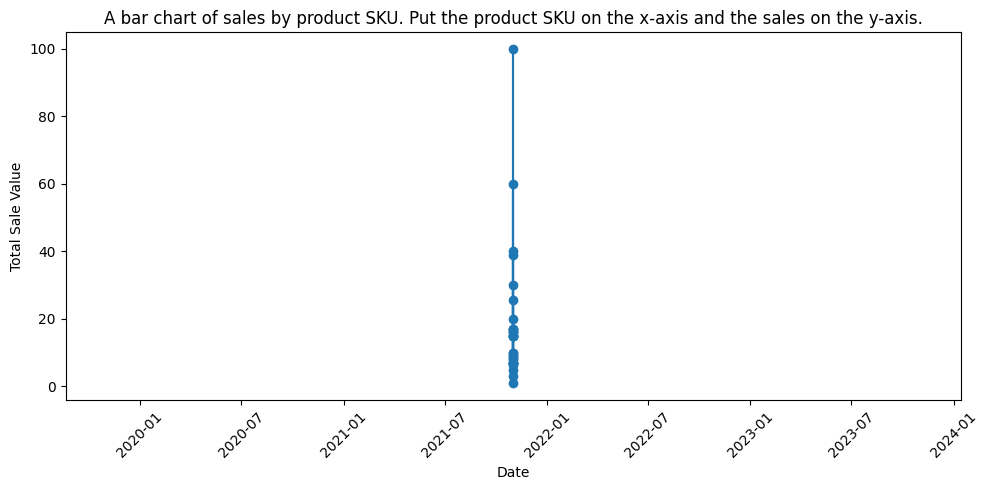

```python
exec(code)
```

## Defining the Router

Now that all of the tools are defined, you can create the router. The router will take the original user input, and is responsible for calling any tools. After each tool call is completed, the agent will return to router to determine whether another tool should be called.

### Tool Schema

Let's define the tools in a way that can be understood by our OpenAI model. OpenAI understands a specific JSON format:

```python
# Define tools/functions that can be called by the model
tools = [
    {
        "type": "function",
        "function": {
            "name": "lookup_sales_data",
            "description": "Look up data from Store Sales Price Elasticity Promotions dataset",
            "parameters": {
                "type": "object",
                "properties": {
                    "prompt": {"type": "string", "description": "The unchanged prompt that the user provided."}
                },
                "required": ["prompt"]
            }
        }
    },
    {
        "type": "function",
        "function": {
            "name": "analyze_sales_data",
            "description": "Analyze sales data to extract insights",
            "parameters": {
                "type": "object",
                "properties": {
                    "data": {"type": "string", "description": "The lookup_sales_data tool's output."},
                    "prompt": {"type": "string", "description": "The unchanged prompt that the user provided."}
                },
                "required": ["data", "prompt"]
            }
        }
    },
    {
        "type": "function",
        "function": {
            "name": "generate_visualization",
            "description": "Generate Python code to create data visualizations",
            "parameters": {
                "type": "object",
                "properties": {
                    "data": {"type": "string", "description": "The lookup_sales_data tool's output."},
                    "visualization_goal": {"type": "string", "description": "The goal of the visualization."}
                },
                "required": ["data", "visualization_goal"]
            }
        }
    }
]

# Dictionary mapping function names to their implementations
tool_implementations = {
    "lookup_sales_data": lookup_sales_data,
    "analyze_sales_data": analyze_sales_data,
    "generate_visualization": generate_visualization
}
```

### Router Logic

The router is composed of a main loop method, and a method to handle the tool calls that you get back from the model.

[figure not shown]

The following two cells define the function `handle_tool_calls` and the variable `SYSTEM_PROMPT`, which will be used by the function `run_agent` defining the router logic.

```python
# code for executing the tools returned in the model's response
def handle_tool_calls(tool_calls, messages):

    for tool_call in tool_calls:
        function = tool_implementations[tool_call.function.name]
        function_args = json.loads(tool_call.function.arguments)
        result = function(**function_args)
        messages.append({"role": "tool", "content": result, "tool_call_id": tool_call.id})

    return messages
```

```python
SYSTEM_PROMPT = """
You are a helpful assistant that can answer questions about the Store Sales Price Elasticity Promotions dataset.
"""
```

```python
def run_agent(messages):
    print("Running agent with messages:", messages)

    if isinstance(messages, str):
        messages = [{"role": "user", "content": messages}]

    # Check and add system prompt if needed
    if not any(
            isinstance(message, dict) and message.get("role") == "system" for message in messages
        ):
            system_prompt = {"role": "system", "content": SYSTEM_PROMPT}
            messages.append(system_prompt)

    while True:
        print("Making router call to OpenAI")
        response = client.chat.completions.create(
            model=MODEL,
            messages=messages,
            tools=tools,
        )
        messages.append(response.choices[0].message)
        tool_calls = response.choices[0].message.tool_calls
        print("Received response with tool calls:", bool(tool_calls))

        # if the model decides to call function(s), call handle_tool_calls
        if tool_calls:
            print("Processing tool calls")
            messages = handle_tool_calls(tool_calls, messages)
        else:
            print("No tool calls, returning final response")
            return response.choices[0].message.content
```

```python
result = run_agent('Show me the code for graph of sales by store in Nov 2021, and tell me what trends you see.')
```

```
Running agent with messages: Show me the code for graph of sales by store in Nov 2021, and tell me what trends you see.
Making router call to OpenAI
Received response with tool calls: True
Processing tool calls
Making router call to OpenAI
Received response with tool calls: True
Processing tool calls
Making router call to OpenAI
Received response with tool calls: True
Processing tool calls
Making router call to OpenAI
Received response with tool calls: False
No tool calls, returning final response
```

```python
print(result)
# you can also print a formatted version of the result
# Markdown(result)
```

````
### Code for Graph of Sales by Store in November 2021

Here’s the Python code to create a graph displaying total sales value by store for November 2021:

```python
import pandas as pd
import matplotlib.pyplot as plt
from io import StringIO

data = """Store_Number,Total_Quantity_Sold,Total_Sales_Value
0,880,1525.0,17753.769956
1,4180,913.0,10213.819920
2,550,764.0,9554.049975
3,1650,1770.0,23186.909958
4,2200,1513.0,16854.439921
5,2310,1594.0,16611.539945
6,1870,1648.0,17091.849894
7,3630,1311.0,14202.299958
8,2420,1370.0,15234.709888
9,660,1208.0,13041.239901
10,770,973.0,9181.769959
11,1100,1712.0,19298.679917
12,3300,1859.0,23730.719905
13,3190,1003.0,11934.999961
14,1210,1821.0,21021.669984
15,2750,1462.0,16310.409961
16,1760,1207.0,14598.209948
17,1980,893.0,9084.959929
18,330,1105.0,12569.599911
19,2970,2312.0,31000.569969
20,2530,890.0,11139.740003
21,3740,949.0,10719.049952
22,4400,225.0,4390.689987
23,990,1280.0,15101.459945
24,3410,1345.0,15982.159946
25,2640,1005.0,10891.639931
26,2090,1080.0,11617.179888
27,4840,1612.0,19127.169971
28,3080,1454.0,18044.450005
29,1320,1701.0,19553.789981
````

[output cut: 24 more lines]

```
   - Store 19 shows the highest quantity sold (2312) and total sales value ($31,000.57), indicating strong performance.

3. **Low Performers**:
   - Store 22 has the lowest sales figures, suggesting issues that need investigation.

4. **Price Point Variability**:
   - Some stores sell high quantities at low prices while others maintain high values with lower quantities, demonstrating different sales strategies.

5. **Seasonal Influence**:
   - Given that the data is from November, there may be holiday-related effects influencing sales patterns.

6. **Recommendations**:
   - Investigate pricing strategies, customer insights, and inventory management for underperforming stores to leverage successful tactics and boost overall sales performance.

This analysis reveals a mix of performance levels across the stores, suggesting targeted strategies could enhance sales success.
```

⬇ **Download Notebooks:** 1) click on the *"File"* option on the top menu of the notebook and then 2) click on *"Download as"* and select *"Notebook (.ipynb)"*.

📒 For more help, please see the *"Appendix – Tips, Help, and Download"* Lesson.